# Welcome to to BIOF076

8/26/2020

## Course Goals

- Give you the skills you need to use R to improve your day to day work.

## Course Overview

- Day 1: Introduction to R; Learning to make basic plots with `ggplot2`
- Day 2: Manipluating data in R; Creating complex plots with `ggplot2`
- Day 3: Created Figures, reports, and posters; Useful Plots to Know
- Day 4: Making Interactive webapps with Shiny
- Day 5: Final Project and Project presentations

## Lecture Format

- Lecture slides + excercies
- Slides are available on the course repo, and in canvas
- exercises are also in the github repo.

## Workship Final Project

- Ideally, you’ll use what you learn in the course to help you with your own work, like
  - creating and assembling multiple plots into a figure for paper,
  - creating a poster for your next conference,
  - building an interactive webapp to explore data with

## Intro to R and other tools

## What is R and why is it good for making visualizations

- R is a programming language designed for statistics
- Researchers who need to use statisticsused R because it is free and open source unlike Stata or SPSS
- Researchers need to make plots and figures to put in publications, so they began developing plotting packages for R
- As biology is growing more and more computational across time, more biologists are using R for analysis and visualization

## Example Visualization

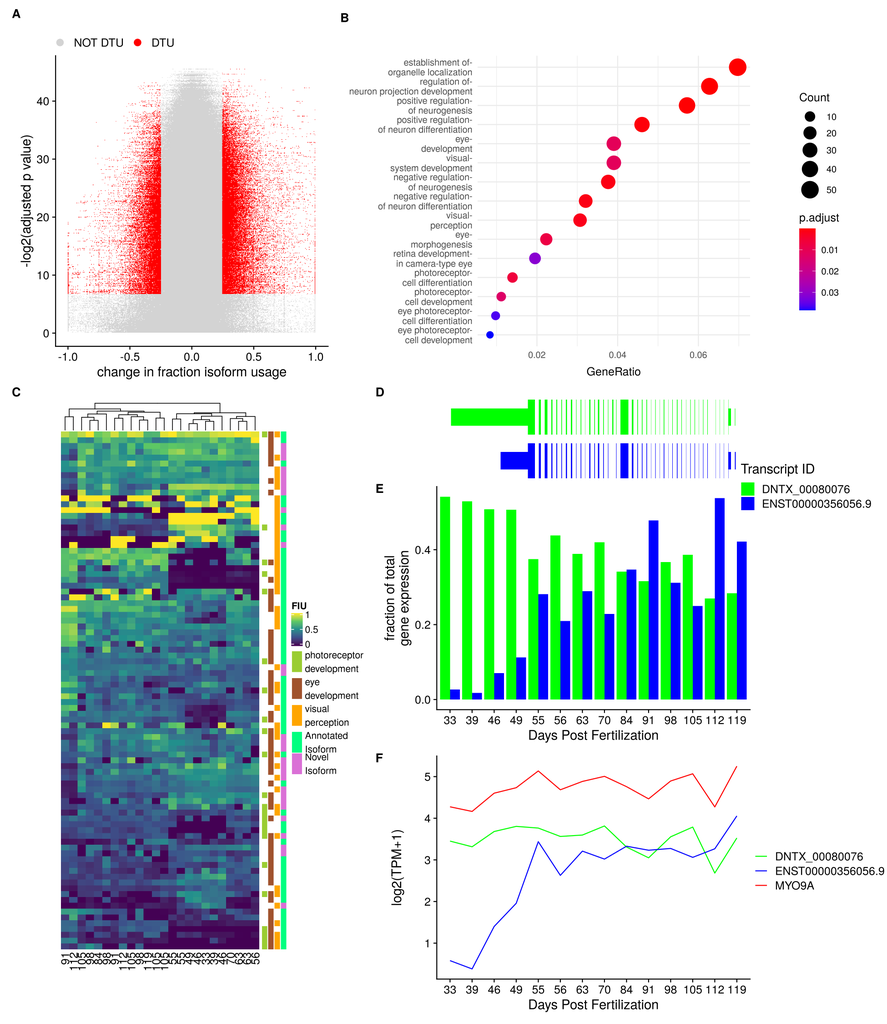

- this is an example of a figure made entirely in R.
- At the end of this course you’ll be able to make something like this

## R is useful for making interactive visualizations

- R also excels at making fast, interactive webapps, like this [covid-19 tracker](https://vac-lshtm.shinyapps.io/ncov_tracker/?_ga=2.255768001.835685898.1601257185-1821184268.1598473205)

## Rstudio

- Rstudio is a integrated development environment for R
- We’ll be using Rstudio for writing and running our code
- The advantage of using Rstudio,is that it offers useful tools like plot viewers, variable exploreres, keyboard shortcuts and more

## Rstudio Overview

## Rproject files

- These are files used by Rstudio, that save your Rstudio environment specific to a certain folder project. For this class, you dont need to know more than opening the project: File > open project > navigate to course folder > XYZ.Rproj

## GitHub

- Github is a website that lets you store code repositories
- GitHub is useful for backing up your code, as well as sharing it with others.
- We’ll be using github for our class

## getting course materials for the course

1. Open Rstudio
2. Go to the terminal in the bottom left panel
3. type in this command git clone https://github.com/vinay-swamy/BIOF076-Visualization-with-R.git